# STA-395 Categorical Data Analysis (Spring 2025)

Last updated: Tue Jan 14 2025, 12:10

## Course Information

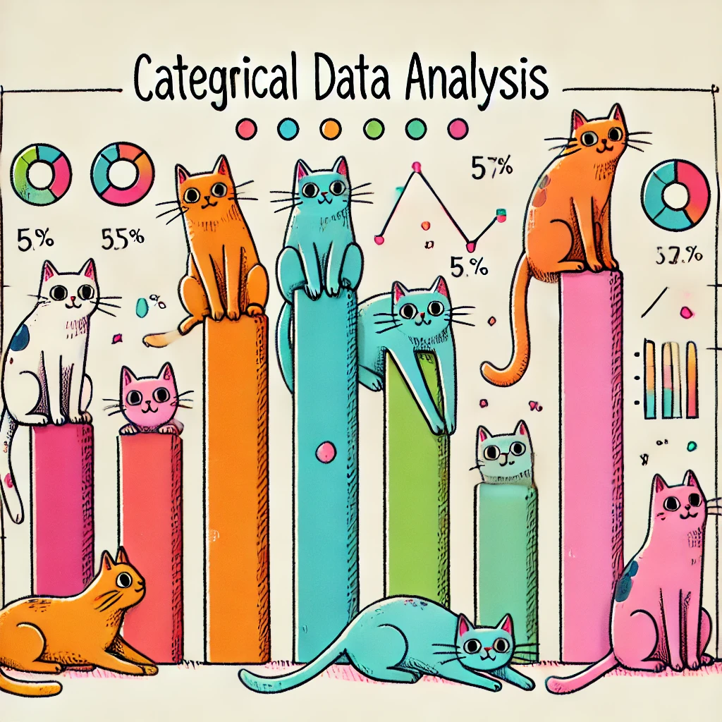

**Instructor**:

- Collin Nolte, Noyce 2216, noltecollin@grinnell.edu

**Class Meetings**:

- STA-395-01 Noyce 2402, TR 8:30-9:50PM

**Office Hours**:

I will plan on hosting the following office hours:

- Monday 10-11
- Monday 3-4 (Community Office Hours)
- Tuesday 10-11
- Thursday 1-2

I am also happy to schedule hours outside of this if there isn’t a time that works for you. Additionally, my door is typically open if you want to stop by

**Gradescope Course numbers**

Not sure yet if we are doing gradescope or physical copies

**Course Description**:

This course will cover a wide range of techniques associated with the analysis of categorical data. This includes descriptions of common discrete sampling distributions, inference on proportions, odds ratios, and one/two/three-way contingency tables, statistical tests for ordinal variables, generalized linear models, and logistic regression.

**Textbook**:

The textbook for this course will be [An Introduction to Categorical Data Analysis, 3rd Edition](https://www.wiley.com/en-us/An+Introduction+to+Categorical+Data+Analysis%2C+3rd+Edition-p-9781119405283) by Alan Agresti.

$~$

### Learning Objectives

After completing this course, students should be able to:

- Identify and analyze categorical data in a variety of contexts
- Perform inference on a proportions, relative risk, and odds ratios
- Understand and explain different methods of association for categorical variables
- Effectively use and communicate results for logistic and generalized linear models

$~$

## Policies

**Class Sessions**

A core component of our class meetings will be working through hands-on labs in a paired programming environment. These pairs will be assigned during the first half of the semester. After the first project, you will have the freedom to choose your partner or work independently near someone that you can occasionally consult with. During labs it is essential that you and your partner(s) work together, making certain that each of you understand your work equally well.

Most labs will begin with a brief “preamble” section that we will go through together as class. The purpose of this section is to introduce the topic of the lab and ensure a smooth start to each class meeting.

**Attendance**

While there is no formal attendance requirement, you will be expected to attend class. Nearly all of the graded content will be delivered through lecture, with course slides and the textbook intending to augment this. Additionally, 10% of your final grade is given through engagement and participation, both of which will prove challenging if you are often absent.

**Software**

Software is increasingly an essential component of statistics and will play an role in this course. We will primarily use `R`, an open-source statistical software program.

You are welcome to use your own personal laptop or a Grinnell College laptop during the course. `R` is freely available and you can download it and it’s UI companion, `R Studio`, here (note: `R` must be downloaded and installed before `R Studio`):

1. Download `R` from http://www.r-project.org/
2. Download `R Studio` from http://www.rstudio.com/

You may also work on a classroom computer, all of which will have `R` and `R Studio` pre-installed.

**Chat GPT**

It is the expectation that Chat GPT will *not* be used for any portion of this course, including homework, projects, worksheets, or exams. Chat GPT is often wrong in very specific ways when addressing academic topics, and you do yourself an exceptional disservice when you offload the struggle of working through a problem onto a robot. Further, it is very easy to tell when a student submission has employed generative AI in writing solutions. Don’t do it, I will be incredibly displeased

$~$

### Grading

I will be employing the following scale for this course:

| Grade | A | A- | B+ | B | B- | C | D |
| --- | --- | --- | --- | --- | --- | --- | --- |
| Range | 94-100 | 90-93 | 87-89 | 83-86 | 80-82 | 70-79 | 60-69 |

Your final numeric score will be rounded to the nearest integer.

Generally speaking, grades will not be curved unless there is a serious miscalibration in difficulty on my part.

**Engagement and Participation** - 10%

While attendance is not formally taken, it will be critical to your success that your regularly show up to class and participate. This includes asking and answering questions, as well as participating in in-class activities.

**Individual Homework** - 20%

There will be six to seven homework assignments throughout the semester that will be a combination of statistical theory and applied problem solving in R. Tentatively, about half of each assignment will be graded on completion and half will be graded for correctness; this breakdown will be provided when the assignment is assigned. Note, however, that just because a particular problem is graded on completion does not mean that you will not be expected to know how to solve it.

If you engage in significant collaboration with classmates, you must explicitly acknowledge that person(s) on the top of your assignment (again, you are encouraged to collaborate, and I want to emphasize that there is no penalty for doing so).

Exams will be announced at least two weeks in advance. They will generally be closed notes. More details to follow.

## Boilerplate

**Academic Honesty**

At Grinnell College you are part of a conversation among scholars, professors, and students, one that helps sustain both the intellectual community here and the larger world of thinkers, researchers, and writers. The tests you take, the research you do, the writing you submit-all these are ways you participate in this conversation.

The College presumes that your work for any course is your own contribution to that scholarly conversation, and it expects you to take responsibility for that contribution. That is, you should strive to present ideas and data fairly and accurately, indicate what is your own work, and acknowledge what you have derived from others. This care permits other members of the community to trace the evolution of ideas and check claims for accuracy.

Failure to live up to this expectation constitutes academic dishonesty. Academic dishonesty is misrepresenting someone else’s intellectual effort as your own. Within the context of a course, it also can include misrepresenting your own work as produced for that class when in fact it was produced for some other purpose. A complete list of dishonest behaviors, as defined by Grinnell College, [can be found here](https://catalog.grinnell.edu/content.php?catoid=12&navoid=2537#alleged-violation).

**Inclusive Classroom**

Grinnell College makes reasonable accommodations for students with documented disabilities. To receive accommodations, students must provide documentation to the Coordinator for Disability Resources, information [can be found here](http://www.grinnell.edu/about/offices-services/accessibility-disability/disability-services). If you plan on using accommodations in this course, you should speak with me as early as possible in the semester so that we can discuss ways to ensure your full participation in the course.

**Religious Holidays**

Grinnell College encourages students who plan to observe holy days that coincide with class meetings or assignment due dates to consult with your instructor in the first three weeks of classes so that you may reach a mutual understanding of how you can meet the terms of your religious observance, and the requirements of the course.

**Title IX and Pregnancy**

Grinnell College is committed to compliance with Title IX and to supporting the academic success of pregnant and parenting students and students with pregnancy related conditions. If you are a pregnant student, have pregnancy related conditions, or are a parenting student (child under one-year needs documented medical care) who wishes to request reasonable related supportive measures from the College under Title IX, please email the Title IX Coordinator at titleix@grinnell.edu. The Title IX Coordinator will work with Disability Resources and your professors to provide reasonable supportive measures in support of your education while pregnant or as a parent under Title IX.

$~$